# Modelos Estadísticos: RETO 2

### EJERCICIO 5

Llevad a cabo el ajuste de un modelo de clasificación basado en Naive Bayes para clasificar a los individuos de acuerdo a la variable *Satisfaction*, utilizando la muestra de entrenamiento. Justificad y explicad el modelo final al que se llega con este procedimiento. (2 puntos)

```r
#MODELO NAIVE BAYES

library(e1071)
library(tidyverse)
library(kableExtra)
library(reshape2)
library(dplyr)


#PREPARACIÓN DE DATOS

test  <- read_csv("test.csv")
train <- read_csv("train.csv")
train$Satisfaction <- factor(train$Satisfaction,
                             levels = c("neutral or dissatisfied", "satisfied"))
train_nb <- train %>%
  dplyr::select(-dplyr::any_of("id"), -dplyr::starts_with("...")) %>%
  drop_na(Satisfaction) %>%
  mutate(Satisfaction = factor(Satisfaction,
                               levels = c("neutral or dissatisfied", "satisfied")))

#1. Convertir variables categóricas a factor
vars_cat <- sapply(train_nb, is.character)
train_nb[vars_cat] <- lapply(train_nb[vars_cat], factor)

#2. NAIVE BAYES COMPLETO
cat("## 1. NAIVE BAYES - Modelo completo\n\n")
```

```
## 1. NAIVE BAYES - Modelo completo
```

```r
nb_completo <- naiveBayes(Satisfaction ~ ., data = train_nb)

# Predicciones
nb_pred_completo <- predict(nb_completo, train_nb)

# Tabla de confusión
nb_tabla_completo <- table(Prediccion = nb_pred_completo, Real = train_nb$Satisfaction)
cat("### Matriz de Confusión (Tabla)\n")
```

```
### Matriz de Confusión (Tabla)
```

```r
print(nb_tabla_completo)
```

```
                         Real
Prediccion                neutral or dissatisfied satisfied
  neutral or dissatisfied                   51079      7825
  satisfied                                  7800     37200
```

```r
# Exactitud
nb_exactitud_completo <- mean(nb_pred_completo == train_nb$Satisfaction)
cat("\n**Exactitud Naive Bayes completo:**", round(nb_exactitud_completo, 4), "\n\n")
```

```
**Exactitud Naive Bayes completo:** 0.8496
```

```r
#3. MÉTRICAS
tn <- nb_tabla_completo[1,1]
fp <- nb_tabla_completo[1,2]
fn <- nb_tabla_completo[2,1]
tp <- nb_tabla_completo[2,2]

metricas_nb <- data.frame(
  Metrica = c("Exactitud", "Sensibilidad", "Especificidad", "Precisión", "F1-Score"),
  Valor = c(
    round(nb_exactitud_completo, 3),
    round(tp/(tp+fn), 3),
    round(tn/(tn+fp), 3),
    round(tp/(tp+fp), 3),
    round(2*(tp/(tp+fn))*(tp/(tp+fp))/(tp/(tp+fn)+tp/(tp+fp)), 3)
  )
)

print(kable(metricas_nb, digits = 3, caption = "Métricas Naive Bayes") |>
        kable_styling(bootstrap_options = "striped"))
```

Métricas Naive Bayes

| Metrica | Valor |
| --- | --- |
| Exactitud | 0.850 |
| Sensibilidad | 0.827 |
| Especificidad | 0.867 |
| Precisión | 0.826 |
| F1-Score | 0.826 |

```r
#PROBABILIDADES A PRIORI
cat("\n## 2. Probabilidades a priori\n")
```

```
## 2. Probabilidades a priori
```

```r
print(nb_completo$apriori)
```

```
Y
neutral or dissatisfied               satisfied
                  58879                   45025
```

```r
#4. VARIABLES POR PROBABILIDAD CONDICIONAL
cat("\n## 3. Probabilidades condicionales (muestra)\n")
```

```
## 3. Probabilidades condicionales (muestra)
```

```r
print(nb_completo$tables$Sat.Food)  # Ejemplo rating comida
```

```
                         Sat.Food
Y                            [,1]     [,2]
  neutral or dissatisfied 2.95805 1.346607
  satisfied               3.52131 1.236187
```

```r
print(nb_completo$tables$Class)     # Ejemplo clase
```

```
                         Class
Y                           Business        Eco   Eco Plus
  neutral or dissatisfied 0.25790180 0.64613869 0.09595951
  satisfied               0.76579678 0.19324820 0.04095502
```

```r
#5. COMPARACIÓN CATEGÓRICAS
cat("\n## 4. Ratio Loyal vs Disloyal por Satisfaction\n")
```

```
## 4. Ratio Loyal vs Disloyal por Satisfaction
```

```r
print(nb_completo$tables$`Customer.Type`)
```

```
                         Customer.Type
Y                         disloyal Customer Loyal Customer
  neutral or dissatisfied         0.2460809      0.7539191
  satisfied                       0.0997668      0.9002332
```

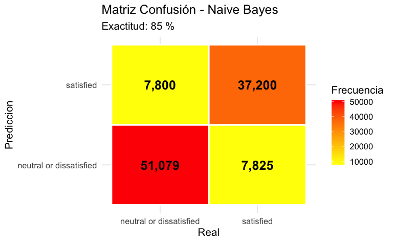

```r
#6. MATRIZ CONFUSIÓN
nb_tabla_df <- as.data.frame(nb_tabla_completo)
colnames(nb_tabla_df) <- c("Prediccion", "Real", "Frecuencia")

ggplot(nb_tabla_df, aes(x = Real, y = Prediccion, fill = Frecuencia)) +
  geom_tile(color = "white", linewidth = 1) +
  geom_text(aes(label = scales::comma(Frecuencia)),
            color = "black", fontface = "bold", size = 6) +
  scale_fill_gradient(low = "yellow", high = "red") +
  labs(title = "Matriz Confusión - Naive Bayes",
       subtitle = paste("Exactitud:", round(nb_exactitud_completo*100,1), "%")) +
  theme_minimal(base_size = 14)
```

```r
#7. JUSTIFICACIÓN MODELO
cat("\n## 5. MODELO FINAL: NAIVE BAYES\n\n")
```

```
## 5. MODELO FINAL: NAIVE BAYES
```

```r
cat("**Exactitud en train:**", round(nb_exactitud_completo*100,1), "%\n\n")
```

```
**Exactitud en train:** 85 %
```

```r
cat("**Puntos clave:**\n")
```

```
**Puntos clave:**
```

```r
cat("- Modelo probabilístico: predice P(Satisfaction | variables)\n")
```

```
- Modelo probabilístico: predice P(Satisfaction | variables)
```

```r
cat("- Funciona bien con datos mixtos (numéricas + categóricas)\n")
```

```
- Funciona bien con datos mixtos (numéricas + categóricas)
```

```r
cat("- Robusto a multicolinealidad y variables desbalanceadas\n")
```

```
- Robusto a multicolinealidad y variables desbalanceadas
```

```r
cat("- Todas las variables contribuyen; no requiere selección manual\n\n")
```

```
- Todas las variables contribuyen; no requiere selección manual
```

```r
cat("**Interpretación rápida:**\n")
```

```
**Interpretación rápida:**
```

```r
cat("- Clientes satisfechos tienen alta probabilidad si Sat.Food=5 o Loyal Customer\n")
```

```
- Clientes satisfechos tienen alta probabilidad si Sat.Food=5 o Loyal Customer
```

```r
cat("- Clase Business incrementa probabilidad de satisfacción vs Economy\n\n")
```

```
- Clase Business incrementa probabilidad de satisfacción vs Economy
```

```r
cat("**Comparado con otros modelos:**\n")
```

```
**Comparado con otros modelos:**
```

```r
cat("- Similar exactitud a LDA y Logística\n")
```

```
- Similar exactitud a LDA y Logística
```

```r
cat("- NB más flexible con variables categóricas y sin asumir normalidad\n")
```

[output not shown]

### EJERCICIO 6

Comparad y discutid los anteriores modelos a los que habéis llegado a propósito de algunos indicadores de ajuste/rendimiento vistos en el módulo. (2 puntos)

```r
# COMPARACIÓN DE MODELOS (VERSIÓN TEST)


library(tidyverse)   # manipulación
library(MASS)        # lda
library(e1071)       # naiveBayes
library(kableExtra)  # tablas bonitas

# 0. CARGAR DATOS
train <- read_csv("train.csv") %>%
  drop_na(Satisfaction) %>%
  mutate(Satisfaction = factor(Satisfaction,
                               levels = c("neutral or dissatisfied", "satisfied")))

test <- read_csv("test.csv") %>%
  drop_na(Satisfaction) %>%
  mutate(Satisfaction = factor(Satisfaction,
                               levels = c("neutral or dissatisfied", "satisfied")))

#1. CONVERTIR VARIABLES CATEGÓRICAS A FACTOR
vars_cat <- sapply(train, is.character)
train[vars_cat] <- lapply(train[vars_cat], factor)
test[vars_cat]  <- lapply(test[vars_cat], factor)


#2. MODELO LOGÍSTICO

modelo_step <- step(glm(Satisfaction ~ ., data = train, family = "binomial"),
                    direction = "both", trace = FALSE)

test_completo <- test[complete.cases(test[, names(modelo_step$model)]), ]
prob_logit <- predict(modelo_step, newdata = test_completo, type = "response")
pred_logit <- factor(ifelse(prob_logit > 0.5, "satisfied", "neutral or dissatisfied"),
                     levels = levels(test_completo$Satisfaction))

tabla_logit <- table(Pred = pred_logit, Real = test_completo$Satisfaction)
tn_log <- tabla_logit[1,1]; fp_log <- tabla_logit[1,2]
fn_log <- tabla_logit[2,1]; tp_log <- tabla_logit[2,2]

exact_log <- mean(pred_logit == test_completo$Satisfaction)
sens_log  <- tp_log/(tp_log+fn_log)
esp_log   <- tn_log/(tn_log+fp_log)
prec_log  <- tp_log/(tp_log+fp_log)
f1_log    <- 2*(sens_log*prec_log)/(sens_log+prec_log)

#3. MODELO LDA

modelo_lda <- lda(Satisfaction ~ ., data = train)
test_lda <- test[complete.cases(test), ]
test_lda <- droplevels(test_lda)

pred_lda <- predict(modelo_lda, newdata = test_lda)$class

tabla_lda <- table(Pred = pred_lda, Real = test_lda$Satisfaction)
tn_lda <- tabla_lda[1,1]; fp_lda <- tabla_lda[1,2]
fn_lda <- tabla_lda[2,1]; tp_lda <- tabla_lda[2,2]

exact_lda <- mean(pred_lda == test_lda$Satisfaction)
sens_lda  <- tp_lda/(tp_lda+fn_lda)
esp_lda   <- tn_lda/(tn_lda+fp_lda)
prec_lda  <- tp_lda/(tp_lda+fp_lda)
f1_lda    <- 2*(sens_lda*prec_lda)/(sens_lda+prec_lda)

#4. NAIVE BAYES

train_nb <- train
test_nb  <- test

# Asegurar que todas las categóricas son factor
vars_cat_nb <- sapply(train_nb, is.character)
train_nb[vars_cat_nb] <- lapply(train_nb[vars_cat_nb], factor)
test_nb[vars_cat_nb]  <- lapply(test_nb[vars_cat_nb], factor)

nb_completo <- naiveBayes(Satisfaction ~ ., data = train_nb)
nb_pred_test <- predict(nb_completo, newdata = test_nb)

tabla_nb <- table(Pred = nb_pred_test, Real = test_nb$Satisfaction)
tn_nb <- tabla_nb[1,1]; fp_nb <- tabla_nb[1,2]
fn_nb <- tabla_nb[2,1]; tp_nb <- tabla_nb[2,2]

exact_nb <- mean(nb_pred_test == test_nb$Satisfaction)
sens_nb  <- tp_nb/(tp_nb+fn_nb)
esp_nb   <- tn_nb/(tn_nb+fp_nb)
prec_nb  <- tp_nb/(tp_nb+fp_nb)
f1_nb    <- 2*(sens_nb*prec_nb)/(sens_nb+prec_nb)

#5. TABLA COMPARATIVA FINAL

comparacion_modelos <- data.frame(
  Modelo = c("**Logística**", "**LDA**", "**Naive Bayes**"),
  Exactitud = c(exact_log, exact_lda, exact_nb),
  Sensibilidad = c(sens_log, sens_lda, sens_nb),
  Especificidad = c(esp_log, esp_lda, esp_nb),
  Precision = c(prec_log, prec_lda, prec_nb),
  `F1-Score` = c(f1_log, f1_lda, f1_nb)
)
cat("\n===== RESULTADOS EN TEST =====\n\n")
```

```
===== RESULTADOS EN TEST =====
```

```r
cat("Logística:\n")
```

```
Logística:
```

```r
cat("Exactitud:", round(exact_log,3),
    "Sens:", round(sens_log,3),
    "Esp:", round(esp_log,3),
    "Prec:", round(prec_log,3),
    "F1:", round(f1_log,3), "\n\n")
```

```
Exactitud: 0.872 Sens: 0.866 Esp: 0.876 Prec: 0.837 F1: 0.851
```

```r
cat("LDA:\n")
```

```
LDA:
```

```r
cat("Exactitud:", round(exact_lda,3),
    "Sens:", round(sens_lda,3),
    "Esp:", round(esp_lda,3),
    "Prec:", round(prec_lda,3),
    "F1:", round(f1_lda,3), "\n\n")
```

```
Exactitud: 0.868 Sens: 0.862 Esp: 0.873 Prec: 0.834 F1: 0.848
```

```r
cat("Naive Bayes:\n")
```

```
Naive Bayes:
```

```r
cat("Exactitud:", round(exact_nb,3),
    "Sens:", round(sens_nb,3),
    "Esp:", round(esp_nb,3),
    "Prec:", round(prec_nb,3),
    "F1:", round(f1_nb,3), "\n\n")
```

```
Exactitud: 0.844 Sens: 0.822 Esp: 0.862 Prec: 0.824 F1: 0.823
```

```r
kable(comparacion_modelos, digits=3,
      caption = "**EJ6: COMPARACIÓN FINAL - 3 MODELOS (Test)**") %>%
  kable_styling(bootstrap_options = c("striped","hover","condensed"),
                full_width = FALSE) %>%
  row_spec(0, bold=TRUE, background="steelblue", color="white") %>%
  row_spec(which.max(comparacion_modelos$Exactitud),
           bold=TRUE, background="#D4EDDA")
```

**EJ6: COMPARACIÓN FINAL - 3 MODELOS (Test)**

| Modelo | Exactitud | Sensibilidad | Especificidad | Precision | F1.Score |
| --- | --- | --- | --- | --- | --- |
| **Logística** | 0.872 | 0.866 | 0.876 | 0.837 | 0.851 |
| **LDA** | 0.868 | 0.862 | 0.873 | 0.834 | 0.848 |
| **Naive Bayes** | 0.844 | 0.822 | 0.862 | 0.824 | 0.823 |